# DM2 : Statistiques avancées

- Montrer tout le code
- Cacher tout le code
- Voir les sources

M2MSR 2023-2024

Auteur·rice

Groupe 11 - Julien ELICES-DIEZ

Date de publication

4 mai 2026

# Énoncé

Dans une étude d’épidémiologie clinique, 146 patients déprimés sont évalués à J0, J4, J7, J14, J21, J28, J42 et J56 à l’aide d’une auto-évaluation (échelle SCL90) et d’une hétéro-évaluation (échelle de dépression de Hamilton).

Nous disposons de 3 jeux de données :

- `groupe.xls` : 2 sous-groupes de patients
- `scl.xls` : échelle d’auto-évaluation SCL90
- `hdrs.xls` : échelle de dépression de Hamilton (HDRS)

###### **Objectifs**

1. Vérifier la validité de l’échelle HDRS à J0 et J56.
2. À partir du score brut de Hamilton, déterminez si les patients du groupe 1 répondent mieux au traitement que les patients du groupe 0 (utiliser d’abord une approche LOCF puis un modèle mixte).
3. Même question en considérant le critère binaire censuré *“réponse au traitement”* défini par une chute de 50% sur l’échelle HDRS par rapport à J0.

**NoteNote**

L’ensemble du code est divisé en 2 types de scripts :

- Préparation des données (`_setup.R`)
- Production des tableaux et figures (`tbl_*.R` ou `fig_*.R`)

Les paramètres et objets définis dans `_setup.R` sont injectés dans les scripts tableaux et figures, exécutés en aval, afin d’éviter toute duplication de code.

Les tableaux et figures numérotés sont précédés de leur script respectif (replié par défaut). Si plusieurs éléments sont produits par un même script, celui-ci est placé soit uniquement devant le premier élément, soit placé à plusieurs reprises avec une numérotation.

L’ensemble du matériel est accessible depuis un dépôt git en cliquant sur </> Code en haut à droite de la page.

Aucun large language model n’est utilisé pour la rédaction du code ou du texte.

**ImportantLe contenu de ce devoir n’est pas corrigé**

```r
source("rv/scripts/rvr.R")
source("rv/scripts/activate.R")

library(conflicted)
library(tidyverse)
library(rlang)
library(labelled)
library(gtsummary)
library(gt)
library(scales)
library(broom.mixed)
library(survival)
library(ggsurvfit)
library(hebstr)

print(conflict_scout())
conflicts_prefer(dplyr::filter)

update_geom_defaults("text", list(family = "Luciole"))

lang_fr()
```

```r
### OPTS -----------------------------------------------------------------------

set_opts(
  acro = acro(PC ~ "composante principale"),
  y = "Effectif",
  bar = lst(
    stat = "count",
    size = 2.5,
    family = set_opts()$font
  )
)

### IMPORT ---------------------------------------------------------------------

easy_read <- \(x) {
  str_glue("data/{x}.xls") |>
    readxl::read_excel(na = c("", "ND")) |>
    set_names(tolower) |>
    mutate(numero = factor(numero))
}

easy_pca <- \(x) {
  x |>
    unite("numero_visit", c(numero, visit)) |>
    column_to_rownames("numero_visit") |>
    drop_na() |>
    prcomp(scale = TRUE)
}

.base <-
  c("hdrs", "scl") |>
  set_names() |>
  map(
    ~ easy_read(.) |>
      mutate(visit = tolower(visit))
  )

.groupe <- easy_read("groupe") |> mutate(groupe = factor(groupe))

### HDRS -----------------------------------------------------------------------

set_hdrs <- \(.visit = NULL) {
  .hdrs <-
    .base$hdrs |>
    mutate(
      hamd16 = coalesce(hamd16a, hamd16b),
      .keep = "unused",
      .after = hamd15
    )

  if (!is_null(.visit)) {
    .hdrs <- .hdrs |> filter(visit %in% .visit)
  }

  return(.hdrs)
}

hdrs <- lst(
  visit = lst(
    num = c(0, 4, 7, 14, 21, 28, 42, 56),
    str = paste0("j", num)
  ),
  item = map(set_names(visit$str), set_hdrs),
  pct = map_df(item, ~ label_p()(nrow(.) / nrow(item$j0))),
  sum = lst(
    long = set_hdrs() |>
      mutate(
        hdrs = rowSums(pick(matches("hamd"))),
        .after = visit,
        .keep = "unused"
      ) |>
      left_join(.groupe, by = "numero") |>
      drop_na(),
    wide = long |>
      pivot_wider(
        names_from = visit,
        values_from = hdrs
      )
  )
)

### SCL ------------------------------------------------------------------------

.dim <- lst(
  "somatisation" = c(1, 4, 12, 27, 40, 42, 48, 49, 52, 53, 56, 58),
  "traits obsessionnels" = c(3, 9, 10, 28, 38, 45, 46, 51, 55, 65),
  "vulnérabilité" = c(6, 21, 34, 36, 37, 41, 61, 69, 73),
  "dépression" = c(5, 14, 15, 20, 22, 26, 29, 30, 31, 32, 54, 71, 79),
  "anxiété" = c(2, 17, 23, 33, 39, 57, 72, 78, 80, 86),
  "hostilité" = c(11, 24, 63, 67, 74, 81),
  "phobies" = c(13, 25, 47, 50, 70, 75, 82),
  "traits paranoïaques" = c(8, 18, 43, 68, 76, 83),
  "traits psychotiques" = c(7, 16, 35, 62, 77, 84, 85, 87, 88, 90),
  "symptômes divers" = c(19, 44, 59, 60, 64, 66, 89)
) |>
  map(~ paste0("q", .))

is_norm <- \(x) x %in% c(0:4)

set_na <- \(x) {
  mutate(x, across(matches("q"), ~ if_else(!. %in% c(0:4, NA), NA, .)))
}

scl <- lst(
  base = .base$scl,
  n = lst(
    row = n_distinct(base$numero),
    col = base |> select(matches("q")) |> ncol(),
    rc = nrow(base) * col
  ),
  value = lst(
    data = base |>
      filter(!if_all(matches("q"), is_norm)) |>
      select(!where(~ unique(is_norm(.)) |> is_true())),
    total = base |>
      pivot_longer(cols = matches("q")) |>
      mutate(across(c(visit, value), ~ factor(.))) |>
      filter(!is_norm(value)),
    ab = drop_na(total),
    na = total |>
      filter(is.na(value)) |>
      mutate(
        visit = str_extract(visit, "(?<=j)\\d+"),
        value = 1
      )
  ),
  dim = names(.dim) |>
    map(
      ~ base |>
        set_na() |>
        transmute("{.}" := rowSums(across(.dim[[.]]), na.rm = TRUE))
    ) |>
    list_cbind(),
  join = base[c("numero", "visit")] |>
    bind_cols(dim) |>
    left_join(
      y = hdrs$sum$long,
      by = join_by(numero, visit)
    )
)

### AUTO EXEC ------------------------------------------------------------------

auto_exec()
```

# 1 Composition de l’échelle HDRS

## 1.1 Description du jeu de données

Le jeu de données `hdrs.xls` était constitué de **1053 observations** pour **19 variables**. Les observations portaient sur **146 sujets** évalués sur **17 items**.

Les items `hamd16a` et `hamd16b`, étant mutuellement exclusifs, ont été fusionnés en un item unique `hamd16`.

Le fichier se présentait au format long, soit **une ligne par visite**. Il contenait **17** valeurs manquantes.

```r
.hdrs |>
  filter(if_any(matches("hamd"), is.na)) |>
  gt_qmd()
```

| numero | visit | hamd1 | hamd2 | hamd3 | hamd4 | hamd5 | hamd6 | hamd7 | hamd8 | hamd9 | hamd10 | hamd11 | hamd12 | hamd13 | hamd14 | hamd15 | hamd16 | hamd17 |
| --- | --- | --- | --- | --- | --- | --- | --- | --- | --- | --- | --- | --- | --- | --- | --- | --- | --- | --- |
| 128 | j7 | NA | NA | NA | NA | NA | NA | NA | NA | NA | NA | NA | NA | NA | NA | NA | NA | NA |

Comme on peut le voir, il s’agissait d’une observation à J7 présente dans le jeu de données bien qu’elle ne comportât aucune valeur numérique.

Il y avait donc **1052 observations complètes**. Toute valeur numérique différente d’un entier compris entre 0 et 2 ou 4 selon l’item pouvait être qualifiée de *valeur aberrante*. Le jeu de données n’en contenait **aucune**.

La proportion de sujets suivis dans le temps était comme suit, avec pour référentiel J0 :

| j0 | j4 | j7 | j14 | j21 | j28 | j42 | j56 |
| --- | --- | --- | --- | --- | --- | --- | --- |
| 100,0% | 95,2% | 93,8% | 91,1% | 88,4% | 87,0% | 83,6% | 82,2% |

Le jeu de données a été transposé au format large afin d’obtenir **une ligne par sujet**.

## 1.2 Distributions des scores par item

Pour une meilleure lisibilité, les 17 items de l’échelle HDRS étaient représentés séparément selon leur cotation.

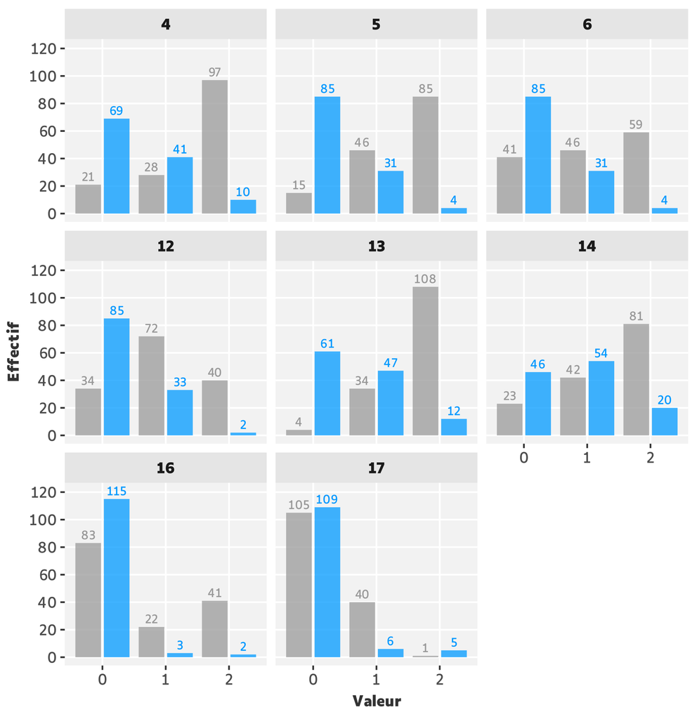

Figure 1. Distribution des items cotés de 0 à 2 sur l’échelle HDRS aux temps **J0** et **J56**.

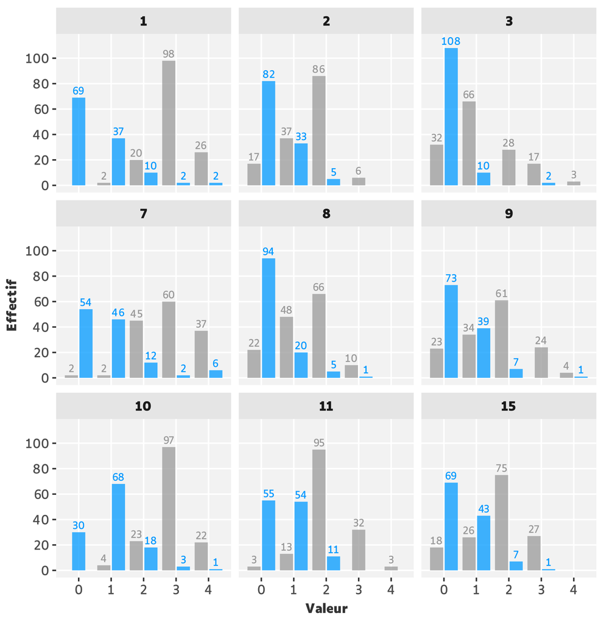

Figure 2. Distribution des items cotés de 0 à 4 sur l’échelle HDRS aux temps **J0** et **J56**.

```r
.bar <- list(
  text = aes(
    y = after_stat(count) + 0.05 * max(count),
    label = after_stat(count),
    color = after_scale(fill)
  ),
  position = position_dodge2(preserve = "single")
)

### GLOBAL ---------------------------------------------------------------------

fig_hdrs_global <- hdrs$sum$long |>
  filter(visit %in% c("j0", "j56")) |>
  ggplot() +
  aes(x = hdrs, fill = visit) +
  geom_histogram(binwidth = 0.25, position = .bar$position) +
  geom_text(
    mapping = .bar$text,
    position = position_dodge(width = 1),
    !!!opts$bar
  ) |>
    inject() +
  labs(x = "Valeur du score global", y = opts$y) +
  scale_x_continuous(n.breaks = 10) +
  scale_y_continuous(n.breaks = 8) +
  scale_fill_manual(values = opts$palette) +
  theme_bar(grid = FALSE)

easy_out(fig_hdrs_global, width = 5.25)

### ITEM -----------------------------------------------------------------------

fig_hdrs_items <- lst(
  n2 = c(4, 5, 6, 12, 13, 14, 16, 17),
  n4 = c(1:17)[-n2]
) |>
  map(
    ~ set_hdrs(.visit = c("j0", "j56")) |>
      pivot_longer(cols = matches("hamd"), names_to = "item") |>
      mutate(item = str_extract(item, "\\d+")) |>
      filter(item %in% .) |>
      ggplot() +
      aes(x = value, fill = visit) +
      facet_wrap(~ as.numeric(item), ncol = 3) +
      geom_bar(alpha = 0.75, position = .bar$position) +
      geom_text(
        mapping = .bar$text,
        position = position_dodge(width = 0.9),
        !!!opts$bar
      ) |>
        inject() +
      labs(x = "Valeur", y = opts$y) +
      scale_y_continuous(n.breaks = 7) +
      scale_fill_manual(values = opts$palette) +
      theme_bar(
        panel.grid.minor = element_blank(),
        panel.background = element_rect(fill = "grey95"),
        strip.background = element_rect(fill = "grey90"),
        strip.text = element_text(face = "bold")
      )
  )

easy_out_map(fig_hdrs_items, height = 6.2, width = 6)
```

De manière approximative on observait une tendance générale à un déplacement vers des scores plus bas à J56, avec parfois un phénomène d’inversion pour certains items.

À noter également, à J56, ce qui pouvait s’apparenter à un *“effet plancher”* sur les items 3 (suicide), 16 (perte de poids) et 17 (prise de conscience). Ces observations convergeaient vers l’idée d’une **amélioration clinique avec le temps**, ce qui paraissait cohérent et rassurant.

Ci-dessous une représentation de la distribution du score HDRS global, obtenu par addition des scores aux 17 items, à J0 et J56.

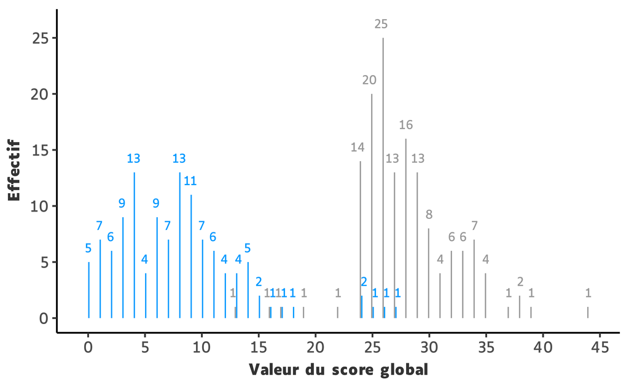

Figure 3. Distribution du score global sur l’échelle HDRS aux temps **J0** et **J56**.  
Le score global provenait de l’addition des scores obtenus aux 17 items pour chaque sujet. Parmi les 146 sujets évalués à J0, 120 (82,2%) étaient évalués à J56.

On pouvait constater une tendance à la baisse du score global. Le calcul des paramètres à toutes les visites mettait en évidence le caractère graduel de cette évolution au cours du temps.

```r
tbl_hdrs <- hdrs$sum$wide |>
  keep(is.numeric) |>
  tbl_wide_summary(statistic = opts$qt_stat_wide, digits = ~1) |>
  modify_header(
    label = str_glue("**Visite**"),
    stat_6 ~ str_glue("**{names(opts$qt_stat$mean)}**")
  ) |>
  gt_format(width = 500)

easy_out(tbl_hdrs)
```

Table 1. Distribution du score global sur l’échelle HDRS en fonction du temps.

| **Visite** | **Min** | **Q1** | **Médiane** | **Q3** | **Max** | **Moyenne±SD** |
| --- | --- | --- | --- | --- | --- | --- |
| j0 | 13,0 | 25,0 | 27,0 | 30,0 | 44,0 | 27,9±4,2 |
| j4 | 7,0 | 23,0 | 25,0 | 28,0 | 42,0 | 25,2±5,3 |
| j7 | 1,0 | 16,0 | 21,0 | 25,0 | 36,0 | 20,8±6,9 |
| j14 | 1,0 | 12,0 | 17,0 | 22,0 | 34,0 | 16,7±6,9 |
| j21 | 0,0 | 8,0 | 14,0 | 20,0 | 34,0 | 14,3±7,4 |
| j28 | 1,0 | 6,0 | 10,0 | 16,0 | 32,0 | 11,5±7,1 |
| j42 | 0,0 | 4,0 | 8,0 | 13,0 | 32,0 | 9,3±6,6 |
| j56 | 0,0 | 4,0 | 7,5 | 10,0 | 27,0 | 7,8±5,5 |

Q1 : 1er quartile ; Q3 : 3e quartile ; SD : écart-type.

On rappelle que les seuils de l’échelle HDRS, basés sur le score global, sont les suivants :

- **<= 7 :** absence de dépression
- **8 à 15 :** dépression mineure
- **>= 16 :** dépression majeure

Par conséquent il y avait à J0 une quasi-totalité de sujets avec dépression majeure. Environ **50%** des sujets évalués à J56 était encore considérés dépressifs, avec cette fois-ci une faible proportion de dépression majeure.

# 2 Validation de l’échelle HDRS à J0 et J56

## 2.1 Analyse factorielle

Une **analyse en composantes principales (PCA)** a été réalisée dans le but d’explorer la structure dimensionnelle de l’échelle HDRS à J0 et J56.

### 2.1.1 Scree plots

Une première étape consistait à déterminer les valeurs propres associées à chaque composante. Il a été choisi de retranscrire celles-ci en *pourcentage de variance capturée* par souci d’en faciliter l’interprétation.

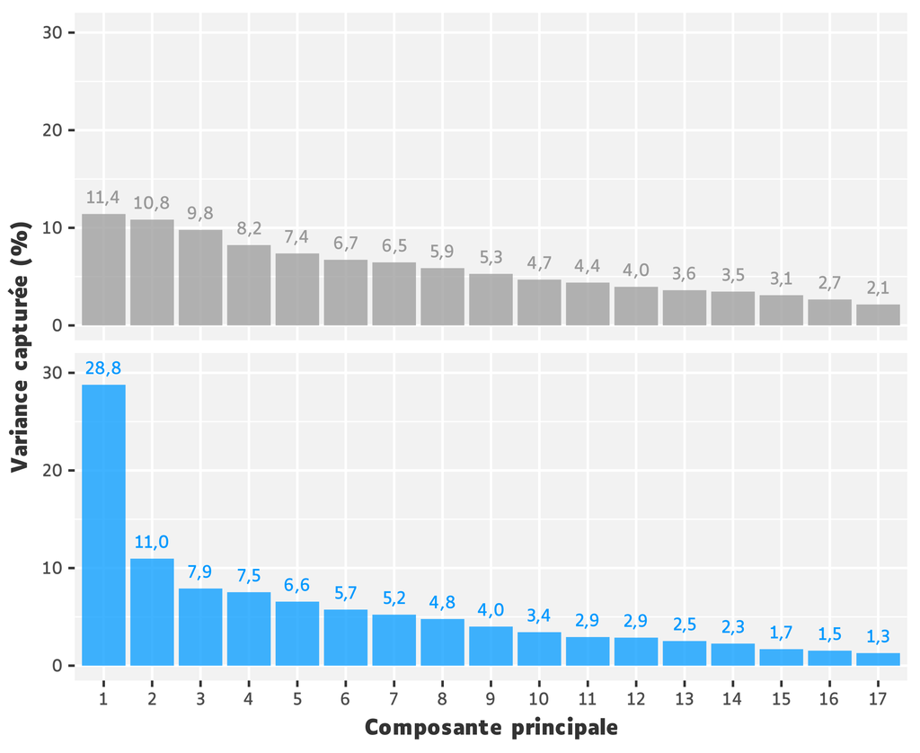

Figure 4. Pourcentage de variance capturée par chaque composante, échelle HDRS à **J0** et **J56**.

```r
.fig_scree_data <- map(
  c("j0", "j56"),
  ~ hdrs$item[[.x]] |>
    easy_pca() |>
    tidy("eigenvalues") |>
    mutate(visit = .)
) |>
  list_rbind()

fig_scree <- .fig_scree_data |>
  ggplot() +
  aes(y = percent, x = factor(PC), fill = visit) +
  facet_wrap(~visit, ncol = 1) +
  geom_col(alpha = 0.75) +
  geom_text(
    mapping = aes(
      y = percent + 0.06 * max(percent),
      label = label_p(suffix = "")(percent),
      color = after_scale(fill)
    ),
    !!!opts$bar[-1]
  ) |>
    inject() +
  labs(x = "Composante principale", y = "Variance capturée (%)") +
  scale_y_continuous(labels = label_percent(suffix = "")) +
  scale_fill_manual(values = opts$palette) +
  theme_bar(
    panel.background = element_rect(fill = "grey95"),
    strip.text = element_blank(),
    axis.text = element_text(size = 7)
  )

easy_out(fig_scree, height = 4.5, width = 5.5)
```

À J0, les deux à trois premières composantes ne semblaient pas capturer une proportion nettement plus importante que les suivantes.

C’était en revanche le cas à J56 avec une PC1 capturant environ **1/3 de la variance totale**, proportion quasiment 3 fois supérieure à celle de la PC2.

**NoteTri sélectif**

De façon arbitraire, nous avons ainsi choisi de sélectionner pour analyse :

- Les **3 premières** composantes à J0
- Uniquement **la première** composante à J56

Ce premier résultat laissait présumer d’un caractère davantage **multidimensionnel à J0** et **unidimensionnel à J56**. L’objectif suivant était de procéder, pour chaque visite, à une analyse factorielle sur la base des dimensions respectivement sélectionnées.

### 2.1.2 Analyse factorielle à J0

L’idée était de voir si pouvaient émerger certains patterns en fonction de la contribution des items à chaque composante, ce qui aurait potentiellement pour effet de révéler la présence de sous-scores dans l’échelle.

```r
### DATA -----------------------------------------------------------------------

.contrib <- lst(
  pc = list(j0 = c("PC1", "PC2", "PC3"), j56 = "PC1") |>
    imap(
      ~ set_hdrs(.y) |>
        easy_pca() |>
        pca_var_extract() |>
        pluck("contrib") |>
        select(column, all_of(.x))
    ),
  max = pc$j0 |>
    rowwise() |>
    mutate(
      column = as.integer(column),
      contrib = round(max(across(matches("PC"))) * 100, 1)
    ) |>
    select(-matches("PC")),
  labels = c(
    "humeur dépressive",
    "sentiment de culpabilité",
    "suicide",
    "insomnie début de nuit",
    "insomnie milieu de nuit",
    "insomnie du matin",
    "travail et activités",
    "ralentissement",
    "agitation",
    "anxiété psychique",
    "anxiété somatique",
    "symptômes gastro-intestinaux",
    "symptômes somatiques généraux",
    "symptômes génitaux",
    "hypocondrie",
    "perte de poids",
    "prise de conscience"
  ),
  palette = c("white", opts$color$warm[2]),
  width = 320
)

easy_sort <- \(x, ..., columns, target_columns = everything()) {
  columns <- enexpr(columns)
  target_columns <- enexpr(target_columns)

  x |>
    set_variable_labels("{columns}" := "contrib. (%)") |>
    gt_heatmap(..., width = .contrib$width) |>
    data_color(
      columns = !!columns,
      target_columns = !!target_columns,
      palette = .contrib$palette
    ) |>
    tab_style(
      style = cell_text(align = "left"),
      locations = list(
        cells_column_labels("description"),
        cells_body("description")
      )
    ) |>
    tab_style(
      style = cell_text(weight = "bold"),
      locations = cells_row_groups()
    )
}

### TBLS -----------------------------------------------------------------------

tbl_contrib_pc <- .contrib$pc$j0 |>
  mutate(across(matches("PC"), ~ round(. * 100, 1))) |>
  gt_heatmap(
    rowname_col = "column",
    width = .contrib$width,
    palette = .contrib$palette
  )

easy_out(tbl_contrib_pc)

tbl_contrib_sort <- list(
  j0 = tibble(
    item = 1:17,
    description = .contrib$labels,
    PC = recode_values(
      item,
      c(2, 3, 6, 9) ~ "PC1",
      c(4, 5, 7, 12, 13, 14, 16) ~ "PC2",
      c(1, 8, 10, 11, 15, 17) ~ "PC3"
    )
  ) |>
    left_join(.contrib$max, by = join_by(item == column)) |>
    mutate(item = as.character(item)) |>
    relocate(PC, contrib, .before = everything()) |>
    arrange(PC, desc(contrib)) |>
    easy_sort(groupname_col = "PC", columns = contrib),
  j56 = tibble(
    PC1 = round(.contrib$pc$j56$PC1 * 100, 1),
    item = as.character(1:17),
    description = .contrib$labels
  ) |>
    easy_sort(arrange = TRUE, columns = PC1)
)

easy_out_map(tbl_contrib_sort)
```

Table 2. **Pourcentage de contribution** des items de l’échelle HDRS à chaque composante principale (PC), à J0.

|  | PC1 | PC2 | PC3 |
| --- | --- | --- | --- |
| 1 | 7,8 | 1,0 | 10,3 |
| 2 | 7,4 | 0,1 | 0,0 |
| 3 | 7,7 | 1,4 | 3,2 |
| 4 | 2,9 | 10,4 | 0,2 |
| 5 | 3,5 | 3,8 | 2,4 |
| 6 | 15,0 | 2,9 | 0,2 |
| 7 | 6,6 | 7,6 | 2,3 |
| 8 | 2,6 | 1,3 | 11,5 |
| 9 | 20,6 | 0,8 | 3,8 |
| 10 | 11,3 | 0,1 | 14,4 |
| 11 | 5,9 | 0,7 | 11,4 |
| 12 | 1,5 | 19,9 | 7,4 |
| 13 | 0,9 | 21,3 | 1,9 |
| 14 | 0,2 | 9,8 | 1,1 |
| 15 | 1,6 | 7,3 | 12,2 |
| 16 | 2,8 | 10,2 | 8,1 |
| 17 | 1,6 | 1,3 | 9,5 |

Table 3. Classement des items de l’échelle HDRS selon leur **contribution** aux composantes principales (PC), à J0.

| contrib. (%) | item | description |
| --- | --- | --- |
| PC1 |  |  |
| 20,6 | 9 | agitation |
| 15,0 | 6 | insomnie du matin |
| 7,7 | 3 | suicide |
| 7,4 | 2 | sentiment de culpabilité |
| PC2 |  |  |
| 21,3 | 13 | symptômes somatiques généraux |
| 19,9 | 12 | symptômes gastro-intestinaux |
| 10,4 | 4 | insomnie début de nuit |
| 10,2 | 16 | perte de poids |
| 9,8 | 14 | symptômes génitaux |
| 7,6 | 7 | travail et activités |
| 3,8 | 5 | insomnie milieu de nuit |
| PC3 |  |  |
| 14,4 | 10 | anxiété psychique |
| 12,2 | 15 | hypocondrie |
| 11,5 | 8 | ralentissement |
| 11,4 | 11 | anxiété somatique |
| 10,3 | 1 | humeur dépressive |
| 9,5 | 17 | prise de conscience |

Le Table 3 est une reprise des données du Table 2 après stratification sur la composante principale (PC) puis classement des items selon leur contribution à celle-ci.

De cette analyse à 3 facteurs, il ne semblait pas se dessiner de profils évidents au sein de chaque composante, hormis peut-être un profil *“somatisation”* en ce qui concerne la PC2.

### 2.1.3 Analyse factorielle à J56

La même analyse à J56, facilitée par la présence d’un seul facteur, permettait de déterminer les items y contribuant en majorité.

Table 4. Classement des items de l’échelle HDRS selon leur **contribution** à la première composante principale, à J56.

| contrib. (%) | item | description |
| --- | --- | --- |
| 12,4 | 1 | humeur dépressive |
| 11,3 | 7 | travail et activités |
| 9,8 | 10 | anxiété psychique |
| 9,4 | 3 | suicide |
| 8,6 | 8 | ralentissement |
| 7,5 | 13 | symptômes somatiques généraux |
| 7,0 | 15 | hypocondrie |
| 5,8 | 2 | sentiment de culpabilité |
| 5,6 | 5 | insomnie milieu de nuit |
| 5,5 | 12 | symptômes gastro-intestinaux |
| 5,3 | 11 | anxiété somatique |
| 3,3 | 6 | insomnie du matin |
| 3,2 | 9 | agitation |
| 2,7 | 4 | insomnie début de nuit |
| 1,7 | 14 | symptômes génitaux |
| 0,6 | 17 | prise de conscience |
| 0,2 | 16 | perte de poids |

Comme on pouvait s’y attendre, l’item *“humeur dépressive”* apparaissait comme étant le plus contributif à la PC1. À noter que les autres items les plus contributifs étaient compatibles avec des caractéristiques souvent retrouvées dans la dépression.

### 2.1.4 PCA globale

Une PCA a été réalisée à partir de l’ensemble du jeu de données, à visée exploratoire *voire expérimentale* (il est donc à noter que les points individuels n’étaient pas indépendants).

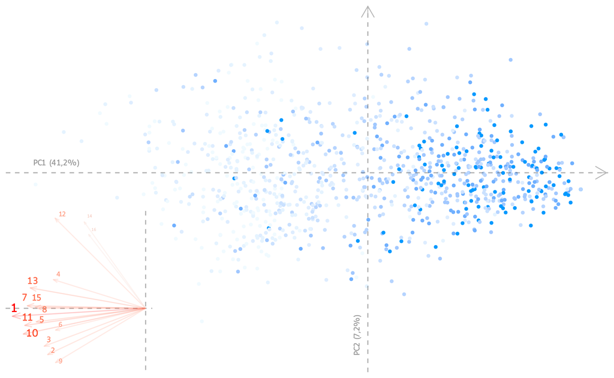

Figure 5. Analyse en composantes principales sur la base du score HDRS, par item, de **J0** à **J56**.  
Les sujets étaient évalués sur 17 items à J0, J4, J7, J14, J21, J28, J42 et J56. Parmi les 146 sujets évalués à J0, 120 (82,2%) étaient évalués à J56. Le nombre associé à la composante est le pourcentage de variance capturée par celle-ci. Les vecteurs correspondent aux items et sont représentés proportionnellement à leur **contribution à la première composante**. PC : composante principale.

```r
.hdrs_data <- set_hdrs()

hdrs$pca <- easy_pca(.hdrs_data)

pc_pct <- \(data, x) {
  data <- data |>
    tidy("eigenvalues") |>
    mutate(p = label_p()(percent))

  lst(p = str_glue("{data$p[{x}]}"), str = str_glue("PC{x} ({p})"))
}

### FIG VAR --------------------------------------------------------------------

.var <- lst(
  data = pca_var_extract(hdrs$pca),
  line = list(linetype = "dashed", alpha = 0.3),
  arrow = arrow(
    angle = 20,
    ends = "first",
    length = unit(0.01 + data$weight * 0.05, "npc")
  )
)

.fig_var <- .var$data$coord |>
  ggplot() +
  aes(x = PC1, y = PC2) +
  list(
    geom_vline(xintercept = 0, !!!.var$line),
    geom_hline(yintercept = 0, !!!.var$line)
  ) |>
    inject() +
  geom_segment(
    mapping = aes(color = .var$data$weight),
    yend = 0,
    xend = 0,
    alpha = 0.2,
    arrow = .var$arrow
  ) +
  ggrepel::geom_text_repel(
    mapping = aes(label = column, color = .var$data$weight),
    hjust = 1,
    size = 0.7 + .var$data$weight * 3,
    box.padding = 0.15,
    nudge_x = 0.01,
    nudge_y = 0.01,
    min.segment.length = Inf,
    family = opts$font
  ) +
  scale_color_continuous(low = "grey90", high = opts$color$warm[2]) +
  theme_pca()

### FIG IND --------------------------------------------------------------------

.ind <- lst(
  data = hdrs$pca |>
    augment() |>
    separate_wider_delim(
      .rownames,
      delim = "_",
      names = c("numero", "visit")
    ) |>
    mutate(visit = str_remove(visit, "j") |> as.integer()) |>
    rename_with(~ str_remove_all(., ".fitted")),
  line = list(linetype = "dashed", alpha = 0.3),
  axis = list(
    geom = "text",
    hjust = 0,
    size = 2.5,
    alpha = 0.4,
    family = opts$font
  ),
  arrow = list(
    linewidth = 0.3,
    color = colorspace::lighten(opts$color$base, 0.3),
    arrow = arrow(length = unit(0.035, "npc"))
  ),
  j_str = unique(.hdrs_data$visit) |>
    toupper() |>
    str_flatten_comma(last = " et "),
  color = list(
    low = opts$color$c[1],
    high = opts$color$c[2],
    vctr = opts$color$w[2]
  )
)

fig_pca <- .ind$data |>
  ggplot() +
  aes(y = PC2, x = PC1, color = visit) +
  geom_point(size = 1) +
  list(
    geom_vline(xintercept = 0, !!!.ind$line),
    geom_hline(yintercept = 0, !!!.ind$line),
    geom_segment(y = 3.9, yend = 4.1, x = 0, xend = 0, !!!.ind$arrow),
    geom_segment(x = 5.15, xend = 5.35, y = 0, yend = 0, !!!.ind$arrow),
    annotate(label = pc_pct(hdrs$pca, 1)$str, x = -7.5, y = 0.25, !!!.ind$axis),
    annotate(
      label = pc_pct(hdrs$pca, 2)$str,
      x = -0.25,
      y = -4.5,
      angle = 90,
      !!!.ind$axis
    )
  ) |>
    inject() +
  annotation_custom(
    ggplotGrob(.fig_var),
    xmin = -8.25,
    xmax = -4.7,
    ymin = -0.75,
    ymax = -5
  ) +
  scale_color_continuous(low = .ind$color$low, high = .ind$color$high) +
  theme_pca()

easy_out(fig_pca, width = 8)
```

La PC1 capturait **41,2%** de la variance totale et on pouvait, après rotation, distinguer les individus en fonction de la visite.

Il ressortait de ce graphique un *“déplacement”* des points individuels dans une direction opposée à celle des vecteurs représentant les items, autrement dit une diminution tendancielle du score à mesure que le temps progressait. On remarquait aussi une moindre dispersion globale des points autour de l’axe à J56, comparé à J0.

Ceci allait dans le sens de ce qui a déjà été montré précédemment, à savoir une **tendance moyenne à l’amélioration clinique au cours du temps**.

## 2.2 Évaluation de la fiabilité

La fiabilité *(consistance interne)* des items de l’échelle HDRS à J0 et J56 pouvait être approchée par le calcul des **coefficients alpha de Cronbach**, accompagnés de leur intervalle de confiance à 95%.

```r
hdrs$visit$str |>
  map(
    ~ hdrs$item[[.]] |>
      drop_na() |>
      select(matches("hamd")) |>
      ltm::cronbach.alpha(CI = TRUE)
  ) |>
  set_names(hdrs$visit$str) |>
  imap(
    ~ tibble(
      visit = .y,
      estimate = .x$alpha,
      conf.low = .x$ci[1],
      conf.high = .x$ci[2]
    )
  ) |>
  list_c() |>
  merge_estim_ci(name = "alpha {opts$ci$label}") |>
  gt_qmd()
```

| visit | alpha [IC95%] |
| --- | --- |
| j0 | 0,46 [0,23 ; 0,60] |
| j4 | 0,70 [0,58 ; 0,78] |
| j7 | 0,82 [0,77 ; 0,86] |
| j14 | 0,84 [0,80 ; 0,87] |
| j21 | 0,87 [0,84 ; 0,89] |
| j28 | 0,87 [0,83 ; 0,90] |
| j42 | 0,87 [0,82 ; 0,90] |
| j56 | 0,82 [0,74 ; 0,86] |

Avec fixation d’un seuil d’acceptabilité à 0,7, la consistance interne de l’échelle HDRS pouvant être considérée **satisfaisante à J56 mais pas à J0**. On constatait que la fiabilité suivait une progression non-linéaire au cours du temps, avec une augmentation importante entre J0 et J4 suivie d’une relative stabilité après J7.

Aux valeurs à J0 et J4 étaient associées des intervalles de confiance plus larges, témoignant d’une moins bonne précision de la mesure à cette période.

**NoteInterprétation**

A J0, la connaissance d’une réponse à un item permettait d’anticiper correctement la réponse aux autres items avec **1 chance sur 2**.

A J56 cette probabilité augmentait à **4 chances sur 5**. Ce gain de fiabilité pourrait être lié au fait que la structure de l’échelle semble, comme nous l’avons montré plus haut, davantage unidimensionnelle à cette période.

## 2.3 Évaluation de la validité

L’évaluation de la fiabilité de l’échelle HDRS ne fournissait pas d’information quant à la nature du construit mesuré. Autrement dit elle ne permettait pas de présupposer de la **validité** de l’échelle.

Afin d’évaluer cette caractéristique nous avons utilisé en tant que *gold standard* l’**échelle auto-évaluative SCL90**, connue pour son caractère multidimensionnel.

**NoteRationnel**

Parmi les 10 dimensions mesurées par SCL90 figurait la dépression. Si l’échelle HDRS avait une bonne capacité à mesurer la dépression en tant que construit, alors son score global devait être davantage corrélé positivement avec le score de la dimension *dépression* de SCL90 (validité **concourante**) qu’avec le score des autres dimensions (validité **divergente**).

### 2.3.1 Composition de l’échelle SCL90

Le jeu de données `scl.xls` était constitué de **1034 observations** pour **92 variables**. Les observations portaient sur **143 sujets** évalués sur **90 items**.

Le jeu de données se présentait au format long, soit **une ligne par visite**.

Toute valeur numérique différente d’un entier compris entre 0 et 4 pouvait être qualifiée de *valeur aberrante*. Il y avait un total de **129 (0,1%) valeurs aberrantes**, dont voici le détail :

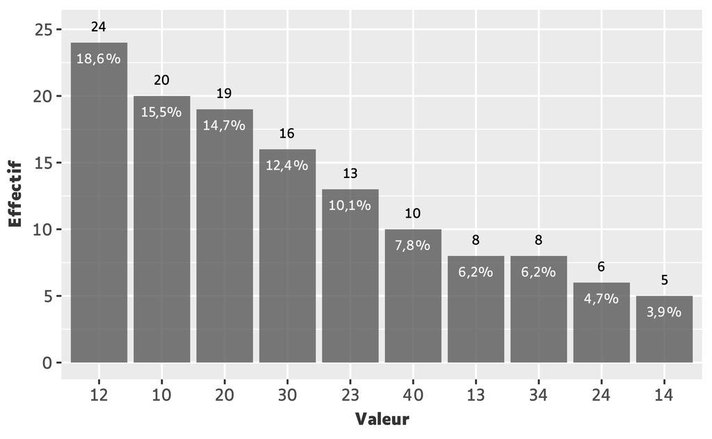

Figure 6. Distribution des valeurs aberrantes dans l’échelle SCL90, par fréquence.  
Était jugée aberrante toute valeur numérique différente d’un entier compris entre 0 et 4 inclus . Le recueil comportait 90 items pour un total de 1034 visites parmi 143 sujets, soit un total de 93060 items. Au total, 129 (0,1%) valeurs aberrantes étaient retrouvées. 48 sujets sur 143 (33,6%) et 60 items distincts sur 90 (66,7%) étaient concernés par au moins une occurrence. Les pourcentages ont pour dénominateur le nombre total de valeurs aberrantes. Aucune valeur décimale n’était retrouvée.

```r
### DATA -----------------------------------------------------------------------

.value_data <- map(
  set_names(c("ab", "na")),
  ~ lst(
    n = scl$value[[.]],
    p = label_p()(nrow(n) / scl$n$rc),
    obs = lst(
      n = n_distinct(n$numero),
      p = label_p()(n / scl$n$row)
    ),
    item = lst(
      n = n_distinct(n$name),
      p = label_p()(n / scl$n$col)
    )
  )
)

.value_params <- list(
  ab = list("Valeur", expr(fct_infreq(value))),
  na = list("Jours", expr(fct_inseq(visit)))
)

### FIG ------------------------------------------------------------------------

fig_value <- imap(
  .value_params,
  ~ .value_data[[.y]]$n |>
    ggplot() +
    aes(x = eval(.x[[2]])) +
    geom_bar(alpha = 0.8) +
    geom_text(
      mapping = aes(
        y = after_stat(count) + 0.05 * max(count),
        label = after_stat(count)
      ),
      !!!opts$bar
    ) |>
      inject() +
    geom_text(
      mapping = aes(
        y = after_stat(count) - 0.05 * max(count),
        label = label_p()(after_stat(count) / sum(after_stat(count)))
      ),
      color = "grey95",
      !!!opts$bar
    ) |>
      inject() +
    labs(x = .x[[1]], y = opts$y) +
    theme_bar()
)

easy_out_map(fig_value, width = 5.5)
```

Il y avait un total de **482 (0,5%) valeurs manquantes**, dont voici le détail :

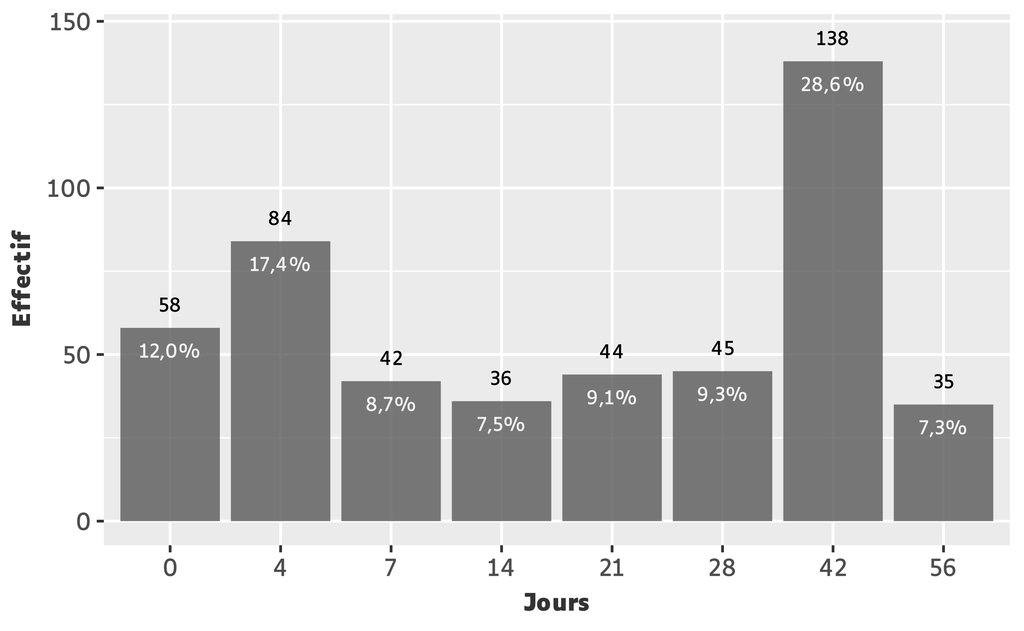

Figure 7. Distribution des valeurs manquantes dans l’échelle SCL90, par visite.  
Le recueil comportait 90 items pour un total de 1034 visites parmi 143 sujets, soit un total de 93060 items. Au total, 482 (0,5%) valeurs manquantes étaient retrouvées. 99 sujets sur 143 (69,2%) et 88 items distincts sur 90 (97,8%) étaient concernés par au moins une occurrence. Les pourcentages ont pour dénominateur le nombre total de valeurs manquantes.

**ImportantGestion des valeurs aberrantes**

Les 129 valeurs aberrantes présentes dans l’échelle SCL90 ont été converties en valeurs manquantes.

Après ce traitement, le jeu de données était composé de **782 (75,6%) observations complètes**.  
Il y avait au total :

- 129 + 482 = **611 (0,7%) valeurs manquantes**
- **104 sujets** et **89 items distincts** étaient concernés par au moins une occurrence

Les 90 items ont ensuite été regroupés par dimensions puis additionnés afin de constituer des sous-scores.

|  | numero | visit | somatisation | traits obsessionnels | vulnérabilité | dépression | anxiété | hostilité | phobies | traits paranoïaques | traits psychotiques | symptômes divers | hdrs | groupe |
| --- | --- | --- | --- | --- | --- | --- | --- | --- | --- | --- | --- | --- | --- | --- |
| 1 | 96 | j0 | 40 | 34 | 9 | 42 | 28 | 24 | 16 | 23 | 21 | 24 | 34 | 0 |
| 2 | 96 | j4 | 26 | 36 | 15 | 42 | 28 | 23 | 12 | 22 | 19 | 24 | 26 | 0 |
| 3 | 96 | j7 | 33 | 22 | 13 | 31 | 26 | 20 | 6 | 20 | 21 | 21 | 12 | 0 |
| 4 | 96 | j14 | 21 | 22 | 11 | 25 | 9 | 12 | 3 | 13 | 15 | 11 | 7 | 0 |
| 5 | 96 | j21 | 7 | 16 | 9 | 22 | 15 | 14 | 1 | 11 | 8 | 9 | 5 | 0 |
| 6..1033 |  |  |  |  |  |  |  |  |  |  |  |  |  |  |
| 1034 | 120 | j28 | 9 | 19 | 17 | 34 | 0 | 3 | 4 | 9 | 14 | 8 | 16 | 0 |

Ce jeu de données final ne contenait **aucune valeur manquante**.

### 2.3.2 Corrélation entre SCL90 et HDRS global

Les **coefficients de corrélation r de Pearson** ont été calculés pour chaque visite afin d’apprécier l’évolution entre J0 et J56.

Figure 8. Coefficients de corrélation de Pearson entre les scores des dimensions de l’échelle SCL90 et le score global sur l’échelle HDRS, par visite.

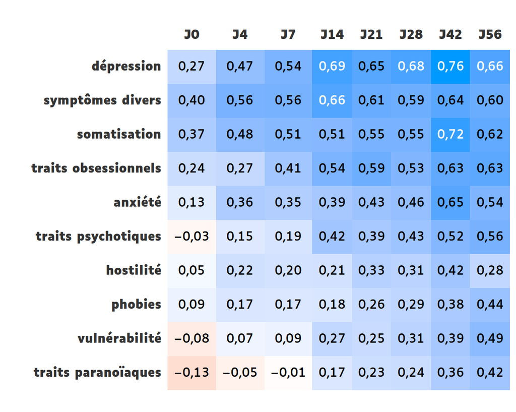

```r
fig_corr <- hdrs$visit$str |>
  map(
    ~ scl$join |>
      filter(visit == .) |>
      corrr::correlate(quiet = TRUE) |>
      select(term, {{ . }} := hdrs) |>
      filter(term != "hdrs") |>
      column_to_rownames("term") |>
      set_names(toupper)
  ) |>
  list_cbind() |>
  rownames_to_column("term") |>
  gt_heatmap(
    rowname_col = "term",
    digit = 2,
    width = 400,
    palette = with(opts$color, c(warm[2], cold[2])),
    arrange = TRUE
  )

easy_out(fig_corr)
```

Les dimensions étaient classées par coefficient moyen décroissant.

On constatait que la corrélation entre le score HDRS global et le score de la dimension *“dépression”* de SCL90 était faible à J0, bien qu’elle figurât parmi les plus élevées. Cependant elle avait tendance à augmenter positivement avec le temps, de même que les autres, jusqu’à un **maximum à J42**.

La dimension *“dépression”* de SCL90 apparaissait comme étant en moyenne **la plus corrélée positivement à HDRS**. On note que les autres dimensions les plus fortement corrélées *(symptômes divers, somatisation)* sont des caractéristiques pouvant classiquement être retrouvées dans la dépression. Ainsi de tels résultats semblaient pertinents sur le plan clinique.

## 2.4 Conclusion

L’échelle HDRS est connue et utilisée pour son caractère supposé unidimensionnel. Sa réévaluation rapide a pu montrer des disparités en termes de performances selon qu’elle fut réalisée à J0 ou à J56.

Une analyse factorielle à J0 nous a conduit à douter de la structure unidimensionnelle de l’échelle à cette période. Toutefois aucun sous-score n’a pu être clairement identifié. La fiabilité ainsi que la validité étaient jugées insuffisantes.

Une analyse factorielle à J56 laissait paraître une structure davantage unidimensionnelle. Elle a pu montrer des résultats satisfaisants en termes de fiabilité et de validité.

**NoteEt la deuxième visite ?**

Il était intéressant de noter qu’un *scree plot* à J4 (non représenté) mettait en évidence un caractère plus franchement unidimensionnel qu’à J0 avec une PC1 capturant **18.7%** de la variance totale, deux fois plus que la PC2 (**9.6%**). Cette observation pouvait conforter l’hypothèse d’un caractère unidimensionnel de l’échelle HDRS **dès J4** et allait dans le sens du gain considérable de fiabilité constaté à cette période.

**NoteHypothèse sur une potentielle multidimensionnalité à J0**

On rappelle que l’échelle HDRS est une hétéro-évaluation. À J0, c’est-à-dire *de novo*, il peut être délicat pour un évaluateur de cerner une symptomatologie dépressive en tant que construit unique. Les visites suivantes portant sur un sujet désormais *“étiqueté”* dépressif, pourrait être à l’oeuvre chez l’évaluateur une sorte d’effet d’ancrage.

# 3 Comparaison intergroupe du score HDRS global

Les 146 sujets évalués avec l’échelle HDRS étaient équitablement divisés en deux groupes :

- **Groupe 0** : 75 sujets (51%)
- **Groupe 1** : 71 sujets (49%)

L’objectif était de déterminer si les sujets du groupe 1 répondaient mieux au traitement que les sujets du groupe 0. Différentes approches ont été utilisées pour répondre à cette question.

## 3.1 Méthode LOCF

La méthode LOCF *(Last Observation Carried Forward)*, simple mais limitée, consistait à imputer aux valeurs manquantes la dernière valeur connue dans l’observation afin de pouvoir calculer la différence entre le score global à J0 et celui à J56 (**= delta J0-J56**), et ce pour chaque sujet.

```r
hdrs$locf <- lst(
  data = hdrs$sum$wide |>
    pivot_longer(cols = matches("j"), values_to = "hdrs", names_to = "visit") |>
    group_by(numero) |>
    fill(hdrs) |>
    ungroup() |>
    pivot_wider(names_from = visit, values_from = hdrs) |>
    mutate(delta = j0 - j56) |>
    select(groupe, delta),
  mean = data |>
    tbl_summary(
      by = groupe,
      label = delta ~ "Δ J0 - J56",
      statistic = list(delta ~ "{mean}±{sd}"),
      digits = delta ~ 2
    ) |>
    add_p(
      test = list(delta ~ "t.test"),
      test.args = all_tests("t.test") ~ list(var.equal = TRUE),
      pvalue_fun = opts$pvalue$format
    ) |>
    add_stat_label(label = ~ names(opts$qt_stat$mean)),
  lm = lst(
    fit = lm(delta ~ groupe, data),
    tidy = tidy(fit, conf.int = TRUE) |>
      merge_estim_ci() |>
      select(term, estimate_ci, p.value)
  )
)
```

Sachant que le jeu de données était composé de **8 visites** pour **146 sujets**, le nombre total d’observations sans données manquantes était de 8 x 146 = **1168**.

Pour rappel le jeu de données comportait **1052 observations sans données manquantes**. Il y avait donc un total de 1168 - 1052 = **116 (9,9%) valeurs manquantes** à imputer par la méthode LOCF.

**NoteNote**

Ce nombre pouvait aussi être calculé à partir d’une transposition du format long au format large, laissant ainsi apparaître l’ensemble des valeurs manquantes.

```r
hdrs$sum$wide
```

```
#> # A tibble: 146 × 10
#>    numero groupe    j0    j4    j7   j14   j21   j28   j42   j56
#>    <fct>  <fct>  <dbl> <dbl> <dbl> <dbl> <dbl> <dbl> <dbl> <dbl>
#>  1 96     0         34    26    12     7     5     1     1     1
#>  2 157    1         27    19    16    11     9     6     3     3
#>  3 22     0         37    35    33    26    26    10     5     4
#>  4 21     0         34    34    30    23    21     7     4     4
#>  5 38     0         44    30    33    31    24    16    10     7
#>  6 37     1         35    34    35    29    27    27    27    25
#>  7 119    0         19    18    10    16    16    19    13    13
#>  8 48     1         30    29    28    21    NA    NA    NA    NA
#>  9 91     1         25    NA    NA    NA    NA    NA    NA    NA
#> 10 89     0         22    NA    NA    NA    NA    NA    NA    NA
#> # ℹ 136 more rows
```

```r
.j_na <- hdrs$sum$wide |>
  labelled::look_for("j") |>
  dplyr::pull(missing)

.j_na
```

```
#>  j0  j4  j7 j14 j21 j28 j42 j56
#>   0   7  10  13  17  19  24  26
```

```r
sum(.j_na)
```

```
#> [1] 116
```

Le calcul du delta J0-J56 nécessitait d’imputer les valeurs manquantes présentes à J0 et J56. Pour rappel il n’y avait aucune valeur manquante à J0. On dénombrait **26 valeurs manquantes à J56**, ce qui représentait :

- 26/1168 = **2,2%** du jeu de données total avec valeurs manquantes
- 26/116 = **22,4%** de l’ensemble des valeurs manquantes

Le **delta J0-56 moyen** dans chaque groupe était le suivant :

| **Caractéristique** | **0** N = 75 | **1** N = 71 | **p-valeur** |
| --- | --- | --- | --- |
| Δ J0 - J56, Moyenne±SD | 19,92±8,68 | 14,79±8,15 | <0,001 |

**NoteNote sur l’approximation à la loi normale**

Les distributions (non-représentées) étaient de forme vaguement gaussiennes. Du fait d’un effectif supérieur à 30 dans chaque groupe, on a considéré vraie l’hypothèse de normalité pour la suite.

On observait une différence de delta moyen de 19,92 - 14,79 = **5,13** entre les deux groupes.

La p-value calculée à l’aide d’un **t-test pour comparaison de 2 moyennes sur échantillons indépendants** nous autorisait à rejeter l’hypothèse d’une absence de différence au risque $\alpha$ = 5%.

Ce résultat pouvait être retrouvé à l’aide d’un **modèle de régression linéaire simple**, avec le delta J0-J56 comme variable dépendante et le groupe comme variable explicative.

| term | estimate_ci | p.value |
| --- | --- | --- |
| (Intercept) | 19,92 [18,00 ; 21,84] | <0,001 |
| groupe1 | -5,13 [-7,89 ; -2,37] | <0,001 |

On retrouvait une ordonnée à l’origine correspondant au delta moyen dans le groupe 0.

Le coefficient de régression estimé indiquait un delta en moyenne inférieur dans le groupe 1 comparativement au groupe 0 : 19,92 - 5,13 = **14,79**.

**NoteInterprétation**

Le groupe 1 bénéficiait en moyenne d’une moins bonne réponse au traitement que le groupe 0.  
Intervalle de confiance et p-value au risque $\alpha$ = 5% étaient en faveur d’une différence statistiquement significative entre les deux groupes.

## 3.2 Modèle de régression linéaire mixte

Une seconde méthode, plus précise et adaptée aux données répétées, était de modéliser la réponse au traitement selon le groupe sur l’ensemble des visites à l’aide un **modèle de régression linéaire mixte**, qui considérerait la variabilité interindividuelle dans l’évolution du score avec des effets aléatoires **intercept et pente** spécifiques aux sujets.

Le modèle consistait à expliquer l’évolution du score HDRS global en fonction du groupe et de la visite, avec un terme d’interaction. La variable `visit` a été recodée en une variable ordonnée permettant de se placer dans le cadre d’une évolution linéaire.

```r
hdrs$lme <- lst(
  data = hdrs$sum$long |>
    group_by(numero) |>
    mutate(visit = seq(visit)),
  fit = nlme::lme(
    fixed = hdrs ~ groupe * visit,
    random = ~ visit | numero,
    data = data
  ),
  tidy = lst(
    data = tidy(fit, conf.int = TRUE) |> split(~effect),
    fix = data$fixed |>
      merge_estim_ci() |>
      select(term, estimate_ci, p.value),
    ran = data$ran_pars |> select(group, term, estimate)
  )
)
```

Les paramètres des effets fixes étaient accompagnés de leur intervalle de confiance à 95%.

**Effets fixes :** `hdrs ~ groupe * visit`

| term | estimate_ci | p.value |
| --- | --- | --- |
| (Intercept) | 30,15 [28,83 ; 31,46] | <0,001 |
| groupe1 | -0,35 [-2,25 ; 1,56] | 0,72 |
| visit | -3,30 [-3,52 ; -3,08] | <0,001 |
| groupe1:visit | 0,76 [ 0,43 ; 1,08] | <0,001 |

**Effets aléatoires :** `visit | numero`

| group | term | estimate |
| --- | --- | --- |
| numero | sd_(Intercept) | 4,88 |
| numero | cor_visit.(Intercept) | -0,41 |
| numero | sd_visit | 0,71 |
| Residual | sd_Observation | 3,88 |

De ces résultats on pouvait tirer l’information suivante :

- Dans le groupe 0, le score global diminuait en moyenne de **3,3** points à chaque visite.
- Dans le groupe 1, il diminuait en moyenne de 3,3 - 0,76 = **2,54** points.

Cette différence était considérée statistiquement significative au seuil $\alpha$ = 5%.

**NoteInterprétation**

La réponse au traitement au cours du temps était en moyenne meilleure dans le groupe 0 que dans le groupe 1.

# 4 Analyse time-to-event

On pouvait enfin répondre à la question en réalisant une **analyse time-to-event**. Cette méthode nécessitait la création d’un évènement binaire nommé *“réponse au traitement”* et défini par une **diminution >= 50% du score global à J0**.

L’analyse présentée ci-dessous rapportait donc pour chaque groupe le risque de non-survenue de l’évènement, simplement qualifiée de *“non-réponse au traitement”*, en fonction du temps.

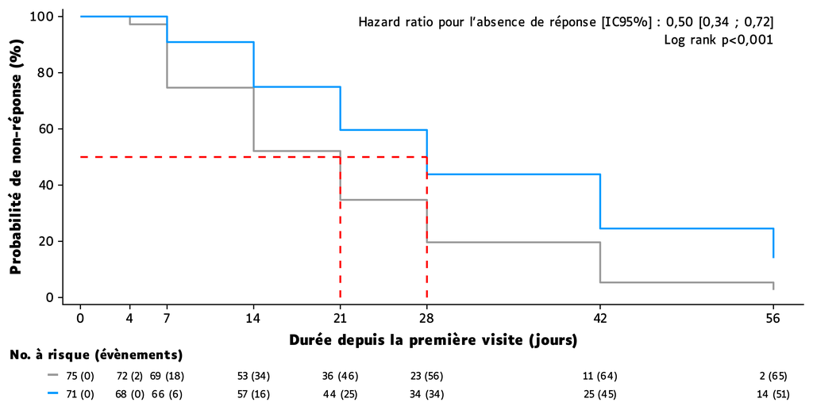

Figure 9. Comparaison de la probabilité de non-réponse au traitement entre les groupes **0** et **1**.  
Les courbes étaient construites suivant la méthode de Kaplan-Meier. **Délai médian avant réponse au traitement**.

```r
### DATA -----------------------------------------------------------------------

.hdrs_surv_data <- hdrs$sum$long |>
  mutate(visit = str_remove(visit, "j") |> as.integer()) |>
  group_by(numero) |>
  mutate(
    bin = if_else(hdrs <= 0.5 * hdrs[visit == 0], 1, 0),
    event = if_else(sum(bin) >= 1, 1, 0),
    time = if_else(
      event == 1,
      visit[bin == 1][1],
      max(visit[bin == 0])
    )
  ) |>
  ungroup() |>
  select(numero, groupe, event, time) |>
  distinct()

### MODEL ----------------------------------------------------------------------

.hdrs_surv_model_fit <- exprs(Surv(time, event) ~ groupe, .hdrs_surv_data)

.hdrs_surv_model_tte <- lst(
  obj = do.call("survfit2", .hdrs_surv_model_fit),
  tidy = tidy_survfit(obj) |>
    split(~strata) |>
    map(
      ~ . |>
        unite(
          "n.event/censor",
          n.event:n.censor,
          sep = "/",
          remove = TRUE
        ) |>
        unite(
          "cum.event/censor",
          cum.event:cum.censor,
          sep = "/",
          remove = TRUE
        ) |>
        merge_estim_ci() |>
        select(time, starts_with(c("n", "cum")), estimate_ci)
    )
)

.hdrs_surv_model_cox <- lst(
  obj = do.call("coxph", .hdrs_surv_model_fit),
  tidy = tidy(obj, exp = TRUE, conf.int = TRUE) |>
    merge_estim_ci() |>
    mutate(
      str = "Hazard ratio pour l'absence de réponse",
      p.value = style_pvalue(
        p.value,
        digits = 1,
        prepend_p = TRUE
      )
    )
)

### FIG ------------------------------------------------------------------------

fig_surv <- .hdrs_surv_model_tte$obj |>
  ggsurvfit() +
  add_quantile(y_value = 0.5, color = opts$color$w[2]) +
  add_risktable(
    risktable_stats = c("{n.risk} ({cum.event})"),
    stats_label = list("{n.risk} ({cum.event})" = "No. à risque (évènements)"),
    risktable_group = "risktable_stats",
    size = 2,
    theme = theme_risktable(plot_margin = 5)
  ) +
  add_risktable_strata_symbol(symbol = "\U2014", size = 8) +
  geom_text(
    data = .hdrs_surv_model_cox$tidy,
    mapping = aes(
      label = str_glue(
        "{str} {opts$ci$label}{opts$sep$int}{estimate_ci}
        Log rank {p.value}"
      )
    ),
    x = 56,
    y = 1,
    hjust = 1,
    vjust = 1,
    size = 2.5
  ) +
  scale_ggsurvfit(
    x_scales = list(
      name = "Durée depuis la première visite (jours)",
      breaks = hdrs$visit$num,
      limits = c(0, 57)
    ),
    y_scales = list(
      name = "Probabilité de non-réponse (%)",
      breaks = seq(0, 1, by = 0.2),
      labels = label_percent(suffix = "")
    )
  ) +
  scale_color_manual(values = opts$palette) +
  theme_tte()

easy_out(fig_surv, height = 3.25, width = 6.5)
```

Le **délai médian jusqu’à réponse au traitement** était de **21 jours dans le groupe 0** et de **28 jours dans le groupe 1**. Il n’y avait pas de croisement entre les courbes de Kaplan-Meier, et le **test du log rank** autorisait à affirmer une différence statistiquement significative entre les groupes au risque $\alpha$ = 5%.

**NoteNote**

Le nombre de mesures sur la période considérée étant restreint et relativement arbitraire, il n’a pas été jugé utile de représenter graphiquement les bandes de confiance, ni même les censures.

De même, la détermination graphique du délai médian jusqu’à évènement pouvait s’avérer artificielle et peu précise. Les données associées à chaque groupe étaient les suivantes :

**Groupe 0**

| time | n.risk | n.event/censor | cum.event/censor | estimate_ci |
| --- | --- | --- | --- | --- |
| 0 | 75 | 0/3 | 0/3 | 1,00 [1,00 ; 1,00] |
| 4 | 72 | 2/1 | 2/4 | 0,97 [0,93 ; 1,00] |
| 7 | 69 | 16/0 | 18/4 | 0,75 [0,65 ; 0,86] |
| 14 | 53 | 16/1 | 34/5 | 0,52 [0,42 ; 0,65] |
| 21 | 36 | 12/1 | 46/6 | 0,35 [0,25 ; 0,48] |
| 28 | 23 | 10/2 | 56/8 | 0,20 [0,12 ; 0,32] |
| 42 | 11 | 8/1 | 64/9 | 0,05 [0,02 ; 0,16] |
| 56 | 2 | 1/1 | 65/10 | 0,03 [0,00 ; 0,16] |

**Groupe 1**

| time | n.risk | n.event/censor | cum.event/censor | estimate_ci |
| --- | --- | --- | --- | --- |
| 0 | 71 | 0/3 | 0/3 | 1,00 [1,00 ; 1,00] |
| 4 | 68 | 0/2 | 0/5 | 1,00 [1,00 ; 1,00] |
| 7 | 66 | 6/3 | 6/8 | 0,91 [0,84 ; 0,98] |
| 14 | 57 | 10/3 | 16/11 | 0,75 [0,65 ; 0,86] |
| 21 | 44 | 9/1 | 25/12 | 0,60 [0,49 ; 0,73] |
| 28 | 34 | 9/0 | 34/12 | 0,44 [0,33 ; 0,59] |
| 42 | 25 | 11/0 | 45/12 | 0,25 [0,16 ; 0,39] |
| 56 | 14 | 6/8 | 51/20 | 0,14 [0,07 ; 0,27] |

Ainsi on pouvait dire de façon un peu plus précise que le délai médian jusqu’à réponse au traitement était situé entre **14 et 21 jours dans le groupe 0** et entre **21 et 28 jours dans le groupe 1**.

Un **modèle de Cox** a été réalisé afin de quantifier le risque de non-réponse au traitement entre les groupes. Les hypothèses suivantes ayant été vérifiées :

- Nombre d’évènements suffisamment grand
- Hypothèse de proportionnalité des risques non rejetée au risque $\alpha$ = 5% (p = 0,486)

Le **hazard ratio** ainsi estimé et présenté sur le graphique fournissait une information qui pouvait être formulée de deux manières équivalentes :

**NoteHR pour l’absence de réponse au traitement = 0.5**

- Il y avait 2 fois plus de risque de ne pas répondre au traitement en étant dans le groupe 1
- Le risque de ne pas répondre au traitement était divisé par 2 dans le groupe 0 comparativement au groupe 1

# 5 Conclusion générale

L’objectif était de comparer l’efficacité d’un traitement contre la dépression entre deux groupes de patients, sur la base d’une différence de score global sur l’échelle HDRS entre les temps J0 et J56.

Une étape préliminaire a consisté à faire une réévaluation rapide de l’échelle HDRS en termes de fiabilité et de validité. Les différentes analyse ont mis en évidence un déséquilibre entre J0 et J56, allant dans le sens à la fois d’un **manque d’unidimensionnalité et de consistance interne** à J0 en comparaison à J56.

Plusieurs méthodes ont été utilisées pour répondre à la question principale :

- **Test de Student** pour comparaison de moyennes calculées à l’aide d’une imputation des valeurs manquantes par la méthode LOCF (+ régression linéaire simple)
- **Modèle linéaire mixte** avec intercept et pente aléatoires spécifiques aux sujets
- **Analyse time-to-event** avec pour évènement une *chute >= 50% du score global à J0*

Ces différentes méthodes ont mené à la conclusion que, en moyenne, la réponse au traitement était significativement meilleure dans le groupe 0 que dans le groupe 1.